# Ilustración del Teorema de Límite Central

Shu Wei

2023-03-24

## Teorema de Límite Central (simulación)

Este documento ilustra de manera intuitiva el Teorema de Límite Central por medio de simulaciones.

### Población con distribución exponencial

Suponga que $X_1,...,X_n \sim Exp(2)$. Una muestra aleatoria simulada con $n=100$ se observa como sigue:

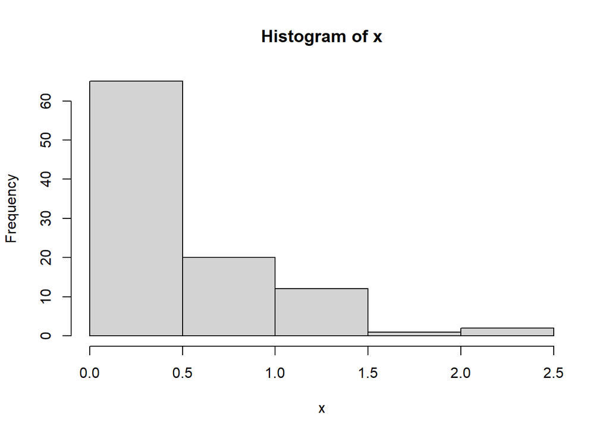

```r
set.seed(100000)
n <- 100
x <- rexp(n,2)
hist(x)
```

```r
mean(x)
```

```
## [1] 0.480446
```

```r
var(x)
```

```
## [1] 0.2243271
```

Observe que teóricamente $E(X)=0.5$ y $Var(X)=0.5^2$.

Ahora, tomo $K=1000$ muestras aleatorias y las guardo en una lista `X`.

```r
K <- 1000
n <- 100
X <- list()
for(i in 1:K){
  X[[i]] <- rexp(n,2) #X es una lista de las K muestras de tamaño 100.
}
```

Calculo la media muestral para $k=1,...,K$ y obtengo la media y variancia (empírica) de las $K=1000$ medias muestrales.

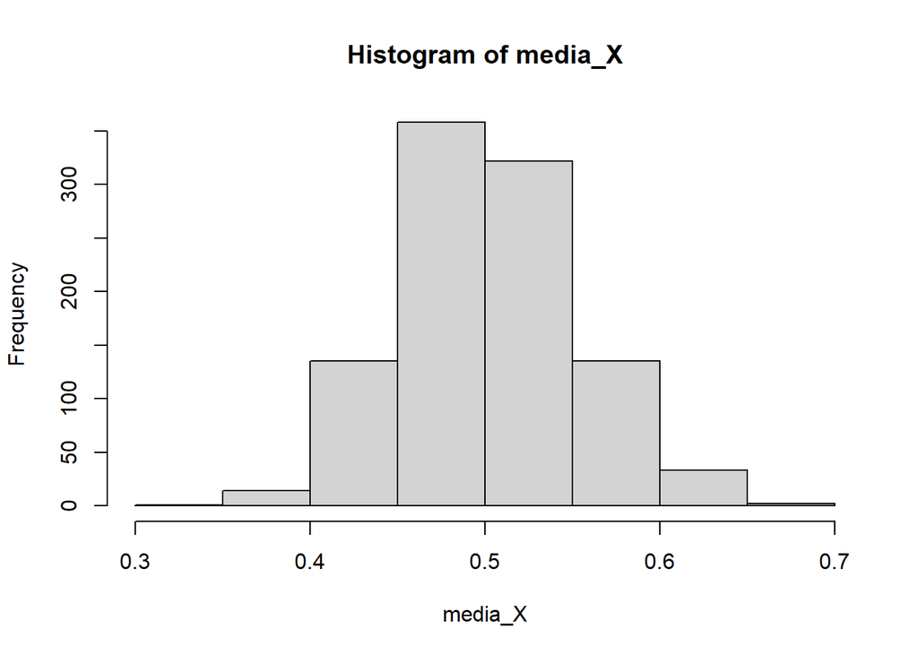

```r
media_X <- sapply(X,mean)
hist(media_X)
```

```r
mean(media_X)
```

```
## [1] 0.5015006
```

```r
var(media_X)
```

```
## [1] 0.002583587
```

Observe que teóricamente $E(\bar{X})=0.5$ y $Var(\bar{X})=0.5^2/n=0.5^2/100=0.0025$. Además, el histograma muestra que con la distribución muestral de $\bar{X}$ es aproximadamente simétrica y quizás normal.

#### Repito el mismo procedimiento para $n=10$

```r
K <- 1000
n <- 10
X <- list()
for(i in 1:K){
  X[[i]] <- rexp(n,2) #X es una lista de las K muestras de tamaño 100.
}
```

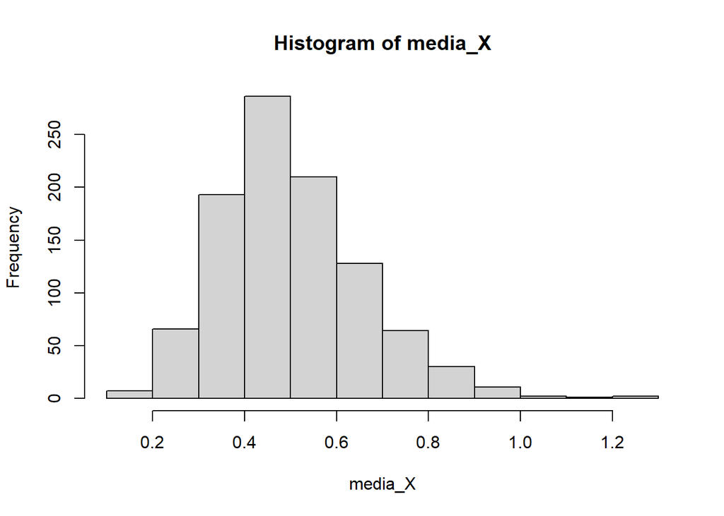

```r
media_X <- sapply(X,mean)
hist(media_X)
```

```r
mean(media_X)
```

```
## [1] 0.5024647
```

```r
var(media_X)
```

```
## [1] 0.02452413
```

Observe que teóricamente $E(\bar{X})=0.5$ y $Var(\bar{X})=0.5^2/n=0.5^2/10=0.025$. Además, el histograma muestra que con la distribución muestral de $\bar{X}$ es asimétrica. Es decir, que no se parece a una distribución normal.

#### Repito el mismo procedimiento para $n=1000$

```r
K <- 1000
n <- 1000
X <- list()
for(i in 1:K){
  X[[i]] <- rexp(n,2) #X es una lista de las K muestras de tamaño 100.
}
```

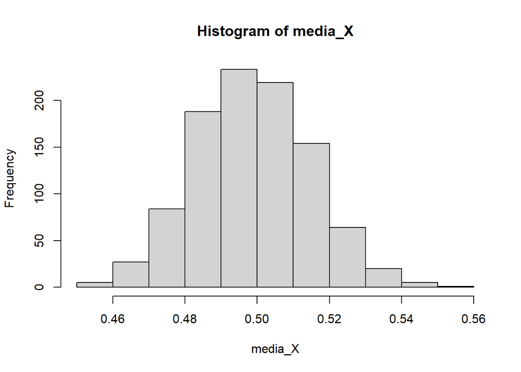

```r
media_X <- sapply(X,mean)
hist(media_X)
```

```r
mean(media_X)
```

```
## [1] 0.4988182
```

```r
var(media_X)
```

```
## [1] 0.0002505538
```

Observe que teóricamente $E(\bar{X})=0.5$ y $Var(\bar{X})=0.5^2/n=0.5^2/1000=0.00025$. Además, el histograma muestra que la distribución muestral de $\bar{X}$ se parece más a los dos casos anteriores. Es decir, que se aproxima más a una distribución normal.

El TLC nos garantiza que
$$Z=\frac{\bar{X}-\mu}{\sigma/\sqrt{n}} \overset{d}{\rightarrow} N(0,1)$$
Es decir, $Z$ se aproxima cada vez a la normal estándar cuando $n\rightarrow \infty$. Por ejemplo, con solo $n=1000$, tenemos

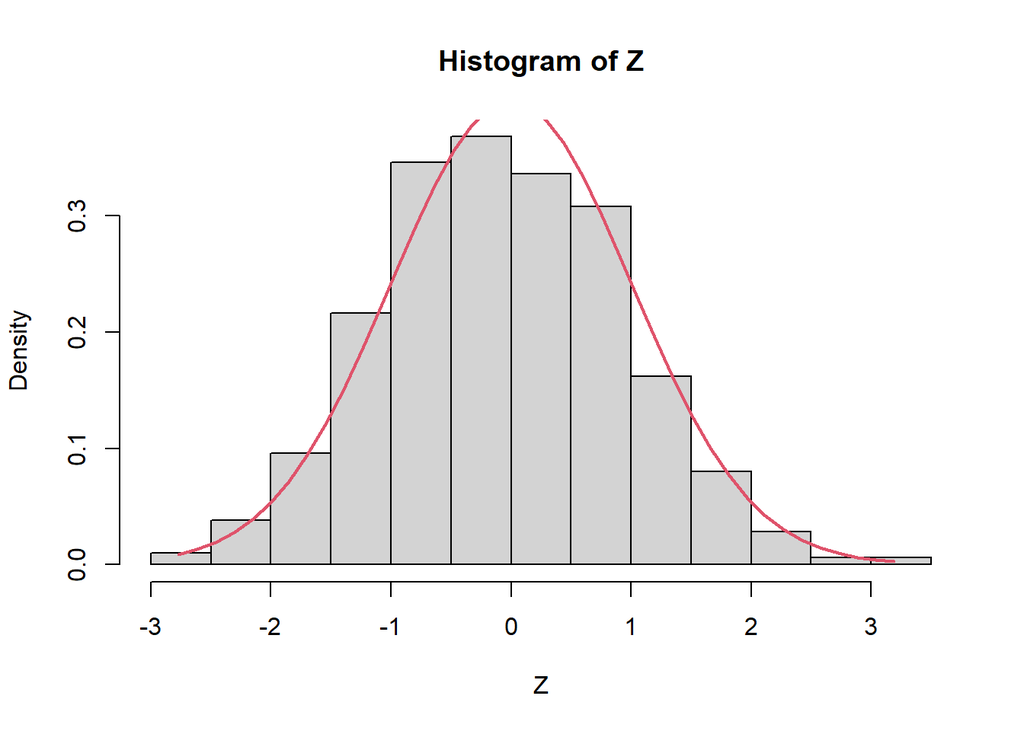

```r
Z=(media_X-0.5)/(sqrt(0.5^2/n))
hist(Z,prob=TRUE)
Z2 <- seq(min(Z), max(Z), length = 40)
lines(Z2, dnorm(Z2, mean = 0, sd = 1), col = 2, lwd = 2)
abline()
```

```r
mean(Z)
```

```
## [1] -0.07474353
```

```r
var(Z)
```

```
## [1] 1.002215
```

### Ejercicios: copiar estos códigos y hagan ustedes el ejercicio aumentando el valor de $n$ gradualmente. Pruebe con distintas distribuciones.